# Species distribution modeling R Workshop II

Ally Phillimore

### Aim

The aim of this second workshop is to download and clean up occurrence (presence only) data from GBIF and then to go through the steps involved with a correlative SDM for presence only data (probably the commonest type) and critiquing a correlative SDM. Quite a lot of what we’ll be doing today is really about data manipulation and we’ll use the latest R packages for spatial analyses - documented at https://rspatial.org/index.html In contrast with the last session, our focus will be more on getting the data in a workable format and getting the analysis to run, rather than focusing on what we’re doing conceptually.

There should be some overlap in terminology with the GIS material you are covering in the *Professional skills* course.

Hopefully, **by the end of this session you will be able to run an SDM for your chosen species.**

We’ll be running the entire session in R today, and there are questions distributed throughout the practical for you to think about.

### Overview

In this session we will cover the following:  
1. Download and clean-up species presence data from GBIF  
2. Select and download climate data from Worldclim  
3. Combine data in a spatraster  
4. Generate background data  
5. Run and evaluate a presence only SDM  
6. Generate a prediction of habitat suitability under a future climate

For this session I have drawn heavily on material provided here: https://rspatial.org/sdm/index.html My thanks to Professors Hijmans and Elith who wrote the rspatial code.

### RSkills

In this session you will gain experience with the following skills:  
1. Downloading data from GBIF and worldclim  
2. Data manipulation  
3. Running Maxent through R  
4. Using spatial (spatraster) data in R and generating maps

### Before we get started

We will run the session today in R and R studio. Please ensure that you have a recent version of each on your computer.

To install a package and its dependencies:

```r
install.packages("geodata",dependencies=TRUE,repos="https://cloud.r-project.org")
install.packages("predicts",dependencies=TRUE,repos="https://cloud.r-project.org")
install.packages("terra",dependencies=TRUE,repos="https://cloud.r-project.org")
```

And then to make the package available to you in R

```r
library(geodata)
library(predicts)
library(terra)
```

I recommend saving your Rscript in an Rscipt file so that you can come back to it. Ideally you’d save your code on Github.

### 1. Downloading data from GBIF

Please choose a focal species that interests you. The session will be most fun if you all confer to make sure everyone looks at a different species. Ideally our choices will span a range of taxonomic groups and regions. Perhaps we can all choose a range of taxa that would allow us an insight into a particular hypothesis, e.g., ectotherms versus endotherms. **At the end of the session it would be really interesting to see which climate variables are important for which taxa and what the model performance is like for different taxa. Try to select a taxon that you think might have an interesting response to climate**

I’ve chosen the rock ptarmigan (*Lagopus mutus*), which breeds at high latitudes in Scotland and is also distributed across the Palearctic and Nearctic. When setting this up the rock ptarmigan had about 13k records, which takes about 1 min to download. The code below includes a start and end value so we only download the first 10000 records, which should keep it manageable time-wise. (If the wi-fi plays up we may need to reduce the number of records. Be aware some rare species have very few records)

```r
occdata <- geodata::sp_occurrence("Lagopus", "muta*", geo=FALSE,removeZeros=TRUE,start=1,end=10000)
```

```
## 10000 records found
```

```
## 0-300-600-900-1200-1500-1800-2100-2400-2700-3000-3300-3600-3900-4200-4500-4800-5100-5400-5700-
## 6000-6300-6600-6900-7200-7500-7800-8100-8400-8700-9000-9300-9600-9900-10000
## 10000 records downloaded
```

In the help page for this function the authors state:

“Under the terms of the GBIF data user agreement, users who download data agree to cite a DOI. Citation rewards data-publishing institutions and individuals and provides support for sharing open data [1][2]. You can get a DOI for the data you downloaded by creating a”derived” dataset. For this to work, you need to keep the “datasetKey” variable in your dataset.”

This all relates to ideas about fair and transparent data that Guillaume has discussed with you.

Once we’ve run the GBIF function we should have a data.frame with as many rows as there are species occurrences.

```r
dim(occdata)
```

```
## [1] 10000   146
```

```r
occdata[1:10,]
```

```
##                 acceptedNameUsageID      acceptedScientificName
## 1                              <NA> Lagopus muta (Montin, 1781)
## 2  urn:lsid:dyntaxa.se:Taxon:102945 Lagopus muta (Montin, 1781)
## 3                              <NA> Lagopus muta (Montin, 1781)
## 4                              <NA> Lagopus muta (Montin, 1781)
## 5  urn:lsid:dyntaxa.se:Taxon:102945 Lagopus muta (Montin, 1781)
## 6  urn:lsid:dyntaxa.se:Taxon:102945 Lagopus muta (Montin, 1781)
## 7  urn:lsid:dyntaxa.se:Taxon:102945 Lagopus muta (Montin, 1781)
## 8                              <NA> Lagopus muta (Montin, 1781)
## 9                              <NA> Lagopus muta (Montin, 1781)
## 10                             <NA> Lagopus muta (Montin, 1781)
##    acceptedTaxonKey accessRights              adm1         adm2
## 1           5227679         <NA>         Trøndelag    Trøndelag
## 2           5227679   Free usage Lycksele lappmark Västerbotten
## 3           5227679         <NA>           Lapland         <NA>
```

[output cut: 502 more lines]

Now we have the data for our species we can plot the global distribution to make sure it fits with our expectation. In the code below replace the path with a location on your computer to store the downloaded data

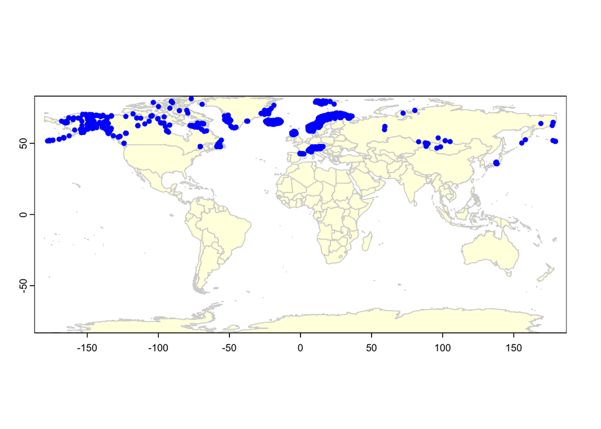

```r
wrld <- world(path=".")
#this function gives us an outline of the world's political boundaries. Reminder, if ever you want to know more about an R function, you can write ?function.name, e.g., ?world
plot(wrld, xlim=c(-180,180), ylim=c(-80,80), col="light yellow", border="light gray")
# add the points
points(occdata$lon, occdata$lat, col='blue', pch=20)
```

### 2. Cleaning up occurrence data

As we saw in the lecture with Polar bears, GBIF data can have quite a few errors, so it’s important to scrutinise them first. A critical step in the process is to make sure that the occurrence data that we have looks correct. Here the ptarmigan data look to be OK, but you might find there are observations at incorrect latitudes. Imagine that we found there were ptarmigan observations in the southern hemisphere - we’d need to remove these records. In the code below I’ve subsetted the data to only include northern hemisphere observations. You may need to take some similar steps to clean your data.

```r
occdata<-subset(occdata,lat>0)
```

Next we’ll look for duplicate records and remove them.

```r
dups <- duplicated(occdata[, c('lon', 'lat')])
#This identifies observations that have already appeared above
sum(dups)
```

```
## [1] 4114
```

```r
#There are a lot of them, so removing them will give us a smaller dataset to work with
occ <- occdata[!dups, ]
```

Questions we should ask ourselves with the occurence data  
- Does the distribution of data look sensible for our selected species?  
- Do we see evidence of spatial biases in sampling?

If we see evidence for spatial bias in sampling, one option is to use subsampling. However we won’t do that here. Usually one would spend a lot longer verifying that the data look correct (for instance for ptarmigan there are a few locations that I’m suspicious of), but for the sake of time we’ll move on.

### 3. Downloading worldclim data

As in our last session, we will download worldclim climate data. Here we will download data at a resolution of 10 minutes (there are 60 minutes in a degree). As with last time, you will need to specify an output_dir specific to your computer. If the code below fails to download the data - let me know as there is a workaround.

```r
output_dir<-"~/Dropbox/teaching/MSC/1_biodiversityunderpressure/SDMs/practicals/practical2_climdata"

bio_glob<-worldclim_global(var="bio", res=10,path=output_dir, version="2.1")

dim(bio_glob)
```

```
## [1] 1080 2160   19
```

bio_glob is in the form of a spatraster (i.e. spatial raster). A raster is simply another name for a spatial grid, and a spatraster combines several of these grids - one for each of the 19 worldclim variables.

```r
#we will also clip the spatraster so it only covers the spatial extent of our study species. First its longitudes then latitudes
summary(occ$lon)
```

```
##     Min.  1st Qu.   Median     Mean  3rd Qu.     Max.
## -177.903  -18.138    9.068   -7.335   16.109  179.290
```

```r
summary(occ$lat)
```

```
##    Min. 1st Qu.  Median    Mean 3rd Qu.    Max.
##   35.68   61.53   64.85   63.50   68.48   81.38
```

```r
e <- ext(-179, 174, 33, 80)

predictors <- crop(bio_glob, e)

names(predictors)<-substring(names(predictors),11,16)
#here we're just shortening the names of predictors by taking the 11th to 16th characters.
```

We can now have a look at the global climate data. Here we’ll just look at the first 9 worldclim variables

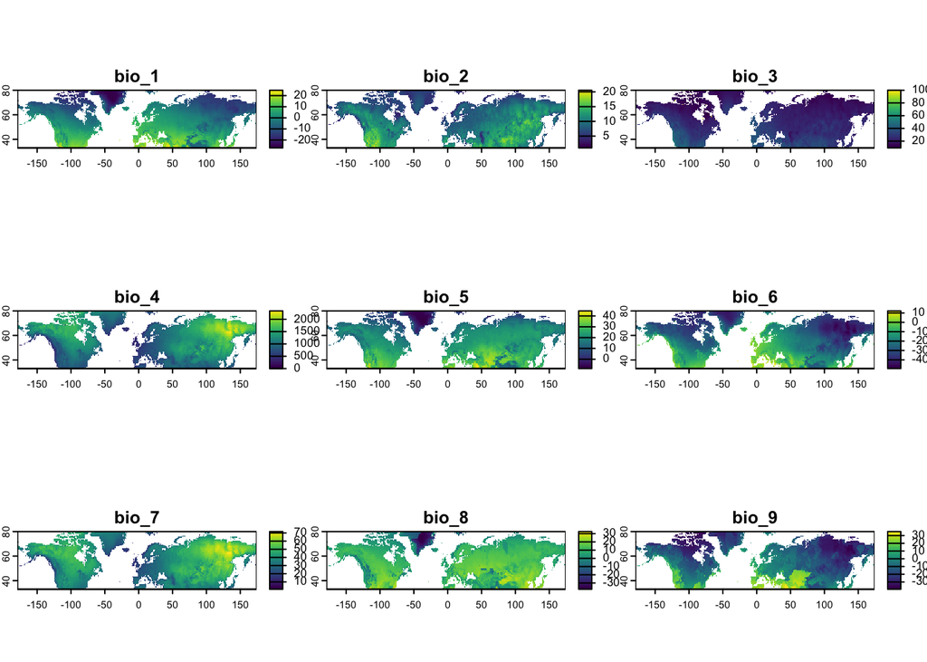

```r
plot(predictors,1:9)
```

And here we can add our species data onto a plot of climate data for the first variable.

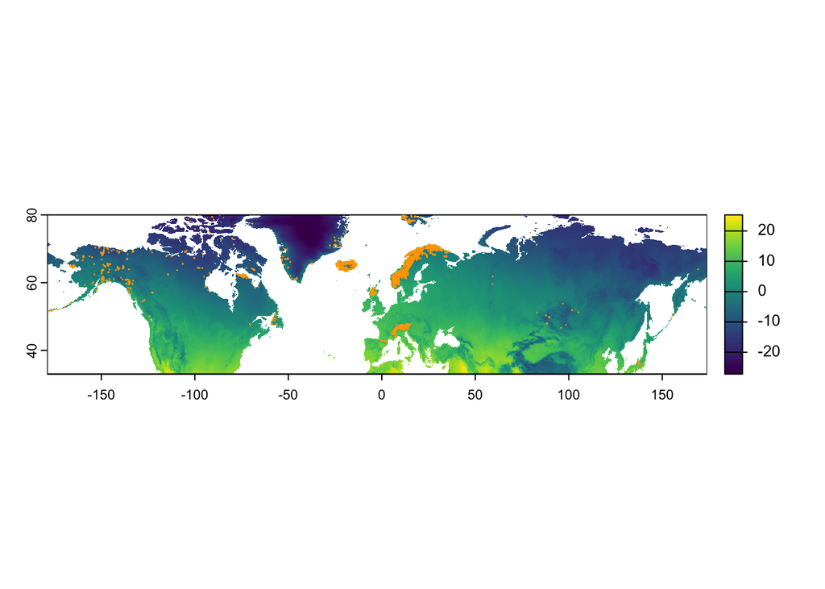

```r
plot(predictors,1)
points(occ$lon,occ$lat, col='orange',pch=16,cex=0.2)
```

### 4. Generating background data

In our last workshop we were working with presence/absence data from an atlas, where the absences were known. Here we are working with occurrence only data. One approach that is widely used is to sample background data from a region - this should cover locations where the species is present and is absent.

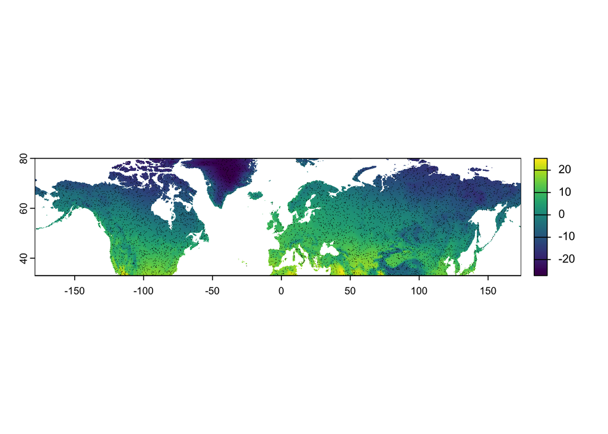

```r
#here I'm setting the spatial extent to be broadly consistent with that of my study species (you need to make sure it is sampling from the same extent). Remember to find out how a function works you can do ?function
#We defined e in an earlier step
bg<-spatSample(predictors,5000,"random", na.rm=TRUE, as.points=TRUE,ext=e)

#Here we'll plot our background points on a map of climwin variable 1 (you could change this to any of the worldclim variables)
plot(predictors, 1)
points(bg, cex=0.1)
```

### 5. Matching occurrence and climate data

Our final step before we can run the model is to match the climate and occurrence data - in the previous workshop this had already been done for us. Here our occurrence data are point data and our climate data are in raster (grid) format, at 10 minute resolution.

```r
occlatlon<-cbind(occ$lon,occ$lat)
presvals <- extract(predictors, occlatlon)
#presvals is the climate data for where the species is present
backvals <- values(bg)
#backvals is the climate data for the background data
bg_lonlat<-geom(bg)
lonlats<-rbind(occlatlon, bg_lonlat[,c("x","y")])
pb <- c(rep(1, nrow(presvals)), rep(0, nrow(backvals)))
#The first column of pb  is a vector of 1s for presences and 0s for background data.
sdmdata <- data.frame(cbind(lonlats,pb, rbind(presvals, backvals)))
#here we combine the presence and background data into a single data frame
```

In sdmdata the first two columns are coordinates and third column contains either a 1 (species present) or 0 (background data). The remaining columns are the corresponding worldclim variables for these location.

We can also examine how colinear (i.e. correlated) predictor variables are. Highly correlated predictor variables can give rise to statistical issues.

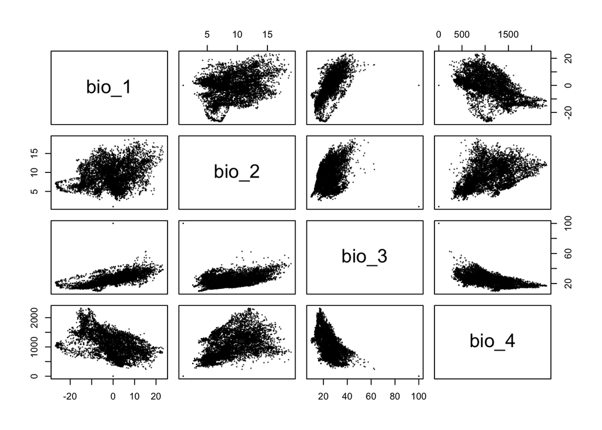

```r
pairs(sdmdata[,4:7], cex=0.1)
```

```r
#Here we just look at the correlations between the first 4 climate variables. You could extend this to look at all 19.
```

### 6. Fitting a species distribution model

Here is a quote from Elith and Hijmans. *“In all cases it is important to use variables that are relevant to the ecology of the species (rather than with the first dataset that can be found on the web!). In some cases it can be useful to develop new, more ecologically relevant, predictor variables from existing data.”*

However, today as we’re trying to cover a lot, we will completely ignore this very important bit of advice!

The predicts package in R allows us to fit a whole variety of functions that are useful in running species distribution models. Next we will use it to run the MAXENT approach that has proven very popular.

WARNING! In 2024 when going through this tutorial I found the next step crashed R when working with R standalone, but runs fine in Rstudio. Googling the issue, others have come across it too. At this stage please write out the data so we can have a plan B. The plan B will be to use the maxent package outside of R, which is downloadable from https://biodiversityinformatics.amnh.org/open_source/maxent/

```r
sdmdata<-subset(sdmdata,is.na(bio_1)==F)
#here we're just removing a couple of rows where the climate data are NAs.


specdata<-as.data.frame(cbind(rep("Lagopus mutu",length(sdmdata[,1])),
sdmdata))

names(specdata)[1:4]<-c("species","longitude","latitude","presabs")

specdata<-subset(specdata,presabs==1)

backdata<-as.data.frame(cbind(rep("background",length(sdmdata[,1])),
sdmdata))

names(backdata)[1:4]<-c("","longitude","latitude","presabs")

backdata<-subset(backdata,presabs==0)


write.table(specdata[,-4],paste(output_dir,"/Lagopusmutu_swd.csv",sep=""),col.names=T,row.names=F,sep=",")
write.table(backdata[,-4],paste(output_dir,"/background.csv",sep=""),col.names=T,row.names=F,sep=",")
```

```r
model<-MaxEnt(sdmdata[,-c(1:3)],sdmdata[,3],removeDuplicates=TRUE)
#Here we've used all of the climate variables, but you could be more discerning.
#We've also asked the model to ignore any data that comes from the same cell.
#In the maxent call we first specify the climate data - these are in all the columns except the first one.
#Next we specify the presence/background data - column1 i.e. [,3]
```

If we then type model into R we get a really neat summary of model performance and the variables that are important as an html doc.

Questions we should ask ourselves with the MAXENT output  
- Are the variables that are found to be important those that you think should be important?  
- Is the AUC value high?

We can also visualise the importance of each variable.

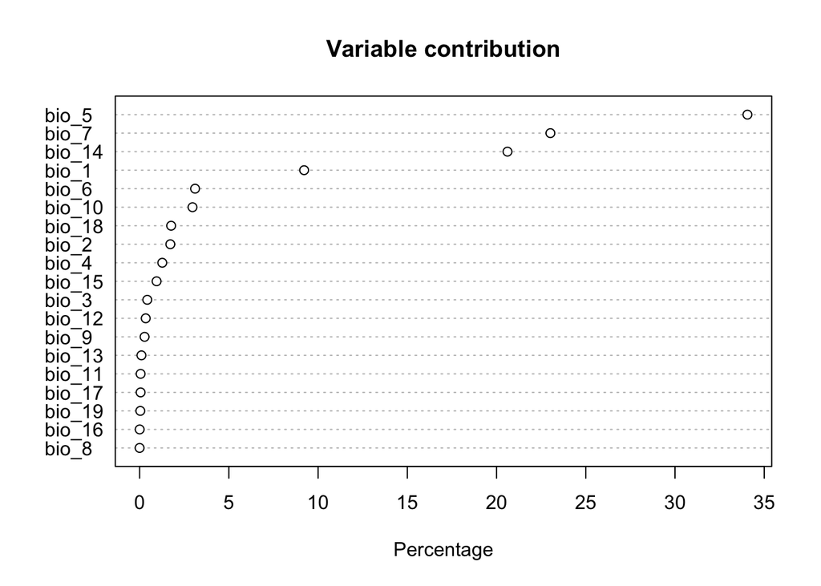

```r
plot(model)
```

The variable that comes out as most important for ptarmigan is bio_5 (https://www.worldclim.org/data/bioclim.html), which is max temperature of the warmest month. I anticipated bio_11 would be most important (mean temperature of the coldest month), but the two predictor variables will be highly correlated.

We can look at the predicted climate suitability globally, and see how it matches where the species has been recorded (remember with occurrence data no data doesn’t mean it is necessarily absent).

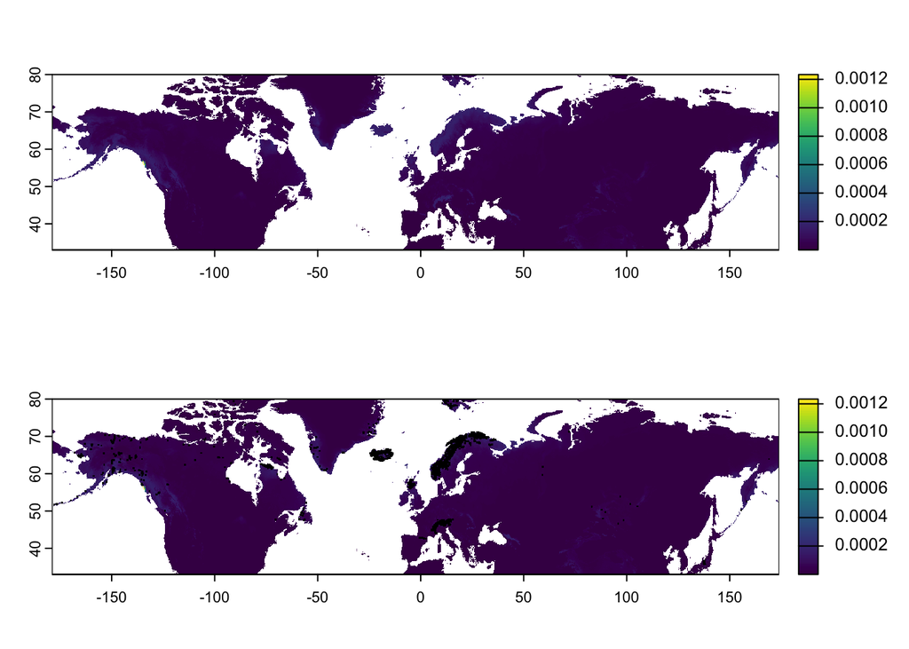

```r
predictedocc <- predict(model, predictors, args=c("outputformat=raw"))

par(mfrow=c(2,1))
plot(predictedocc)
plot(predictedocc)
points(occlatlon,pch=".")
```

### 7. Predicting future distributions

We have one of the elements that we need in order to predict future suitability in that we have the model.

**What else do we need?**

We need to download future climate data.

Below is code to download future climate data. We will use CMIP6 climate data and access it using the cmip6_world function. I suggest running ?cmip6_world to obtain information on how it works. Try the following. Saving the output as bio_fut, obtain data for SSP = “245”, time = “2041-2060”, var=“bioc”, resolution = 10 minutes, path = output_dir. Then as a next step crop the data to your focal extent and name the output fut_predictors. (Again, if you run into problems downloading the files, I have a workaround that I hope will work. Give me a shout).

**If you get stuck, R code is here**

```r
bio_fut<-cmip6_world(model='ACCESS-ESM1-5', ssp='245', time='2041-2060', var='bioc', res=10, path=output_dir)

fut_predictors<-crop(bio_fut,e)
```

Next we can compare baseline to future climates for any of our variables, e.g, (I was surprised to see how subtle the difference appears, but I guess this is because the spatial variation in conditions is so much greater than the temporal shift)

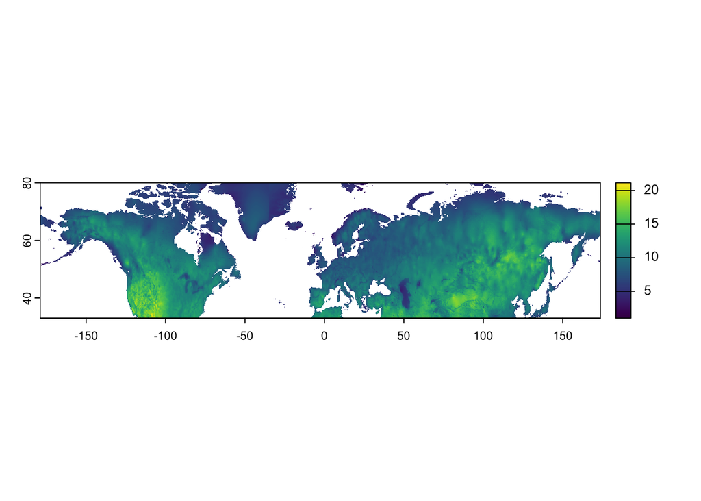

```r
plot(predictors,2)
```

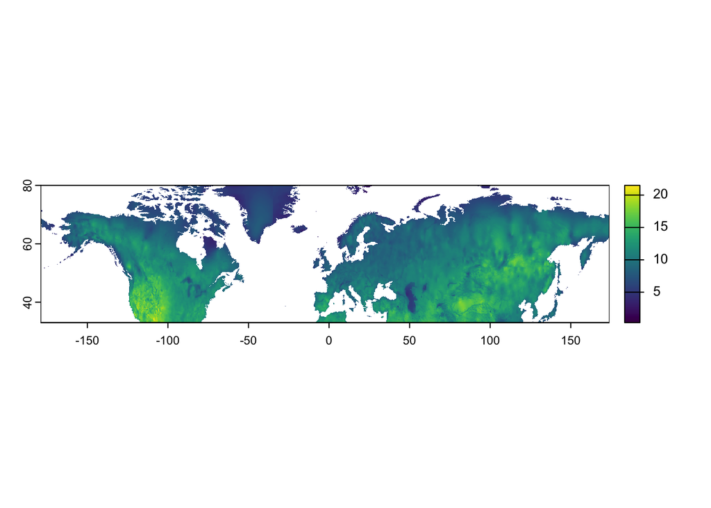

```r
plot(fut_predictors,2)
```

Our final step is to generate a prediction of future climate suitability for our species, but first we’ll need to run this so that the header names correspond

```r
names(fut_predictors)<-names(predictors)
```

**Try to work out how to do this by adapting code you’ve used above**

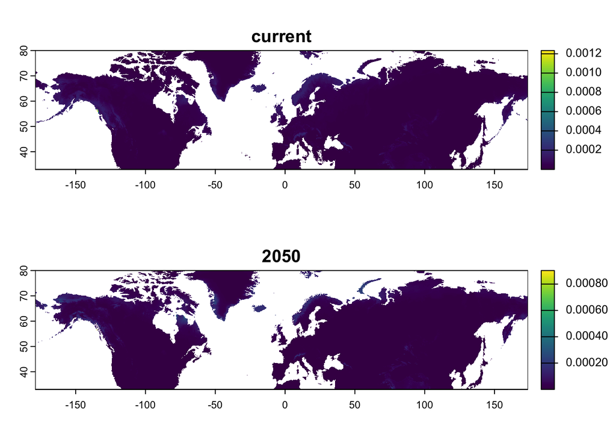

```r
fut_predictedocc <- predict(model, fut_predictors, args=c("outputformat=raw"))

par(mfrow=c(2,1))
plot(predictedocc,main="current")

plot(fut_predictedocc,main="2050")
```

Consider a look at the output you get and answer the following 1. What are the 3 main climate drivers that your species is sensitive to. 2. Has the future area of climate suitability increased or decreased? 3. Is there a clear biogeographic signal to where the suitable climate has moved, e.g., up mountain?

If you’ve raced through this, feel free to run this for another species or run the projection for a more severe SSP.

That’s all on SDMs from me. My hope is that these sessions have given you a clearer understanding of the steps involved, and will provide you with a foundation to build on in the future.